# Psych 254 W15 PS #3

Mike Frank | Completed by Karen LaRocque

February 22, 2015

This is problem set #3, in which we want you to integrate your knowledge of data wrangling with some basic simulation skills and some linear modeling.

```r
library(dplyr)
```

```r
library(ggplot2)
library(lme4)
library(tidyr)
```

# Part 1: Basic simulation and NHST

Let’s start by convincing ourselves that t-tests have the appropriate false positive rate. Run 10,000 t-tests with standard, normally-distributed data from a made up 30-person, single-measurement experiment (the command for sampling from a normal distribution is `rnorm`). What’s the mean number of “significant” results?

First do this using a `for` loop.

```r
sig <- rep(FALSE, 10000)
for (i in seq(1, 10000)) {

  dat <- rnorm(30)
  t <- t.test(dat)
  if (t$p.value < .05) sig[i] = TRUE

}

print(mean(sig))
```

```
## [1] 0.0525
```

```
The proportion of significant results is 0.0525.
```

Next, do this using the `replicate` function:

```r
sig <- replicate(10000, do.call(function(){
                          dat <- rnorm(30);
                          t <- t.test(dat);
                          return(ifelse(t$p.value < .05, TRUE, FALSE))},
                          args = list()))

print(mean(sig))
```

```
## [1] 0.0469
```

```
The proportion of significant results is 0.0469.
```

Ok, that was a bit boring. Let’s try something moderately more interesting - let’s implement a p-value sniffing simulation, in the style of Simons, Nelson, & Simonsohn (2011).

Consider this scenario: you have done an experiment, again with 30 participants (one observation each, just for simplicity). The question is whether their performance is above chance. You aren’t going to check the p-value every trial, but let’s say you run 30 - then if the p-value is within the range p < .25 and p > .05, you optionally run 30 more and add those data, then test again. But if the original p value is < .05, you call it a day, and if the original is > .25, you also stop.

First, write a function that implements this sampling regime.

```r
double.sample <- function (upper_p){

  d <- c()

  repeat{

    d <- append(d, rnorm(30))
    t <- t.test(d)

    if (t$p.value < .05 || t$p.value > upper_p) break

  }

  return(t$p.value < .05)

}
```

Now call this function 10k times and find out what happens.

```r
repl <- replicate(10000, double.sample(.25))
print(mean(repl))
```

```
## [1] 0.0861
```

Is there an inflation of false positives? How bad is it?

```
There is an inflation of false positives, with false positive rate 0.0861. Bad, but not too too bad.
```

Now modify this code so that you can investigate this “double the sample” rule in a bit more depth. Let’s see what happens when you double the sample ANY time p > .05 (not just when p < .25), or when you do it only if p < .5 or < .75. How do these choices affect the false positive rate?

HINT: Try to do this by making the function `double.sample` take the upper p value as an argument, so that you can pass this through dplyr.

HINT 2: You may need more samples. Find out by looking at how the results change from run to run.

```r
sims <- lapply(list(.75, .5), function(x){ mean(replicate(10000, double.sample(x))) })
```

What do you conclude on the basis of this simulation? How bad is this kind of data-dependent policy?

[output not shown]

```r
rm(list = ls())
```

# Part 2: The Linear Model

## 2A: Basic Linear Modeling

Let’s use the `ToothGrowth` dataset, on guineapig teeth based on orange juice and vitamin C. This is super simple. (Try `?ToothGrowth`).

First plot the data, we’ll use `qplot` to understand how `len` (tooth length) depends on `dose` (amount of Vitamin C) and `supp` (delivery method).

`Leaving dose as numeric since it seems that was how it was intended.`

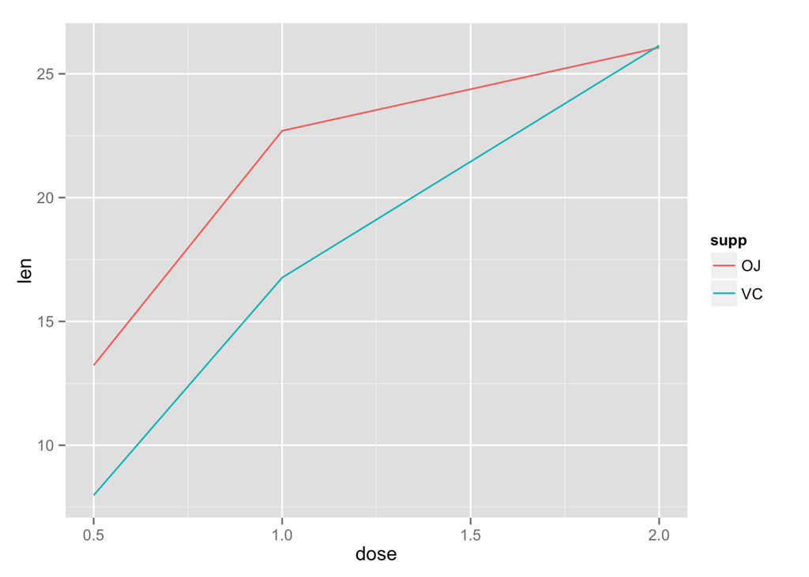

```r
qplot(x = dose, y = len, color = supp, data = ToothGrowth, stat = "summary", fun.y = "mean", geom = "line")
```

So now you see what’s going on.

Next, always make a histogram of the DV before making a linear model! This reveals the distribution and can be helpful in choosing your model type.

```
## stat_bin: binwidth defaulted to range/30. Use 'binwidth = x' to adjust this.
```

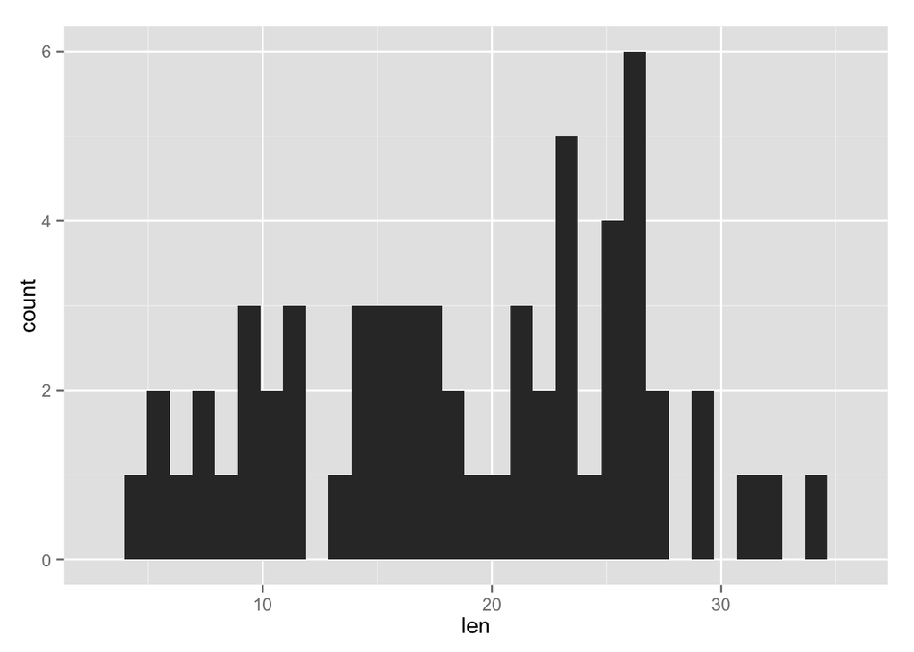

```r
qplot(x = len, data = ToothGrowth)
```

Now make a linear model of tooth lengths using `lm`. Try making one with main effects and interactions and another with just main effects. Make sure to assign them to variables so that you can get them later.

```r
mod_int <- lm(len ~ dose * supp, ToothGrowth)
summary(mod_int)
```

```
##
## Call:
## lm(formula = len ~ dose * supp, data = ToothGrowth)
##
## Residuals:
##     Min      1Q  Median      3Q     Max
## -8.2264 -2.8462  0.0504  2.2893  7.9386
##
## Coefficients:
##             Estimate Std. Error t value Pr(>|t|)
## (Intercept)   11.550      1.581   7.304 1.09e-09 ***
## dose           7.811      1.195   6.534 2.03e-08 ***
## suppVC        -8.255      2.236  -3.691 0.000507 ***
## dose:suppVC    3.904      1.691   2.309 0.024631 *
## ---
## Signif. codes:  0 '***' 0.001 '**' 0.01 '*' 0.05 '.' 0.1 ' ' 1
##
## Residual standard error: 4.083 on 56 degrees of freedom
## Multiple R-squared:  0.7296, Adjusted R-squared:  0.7151
## F-statistic: 50.36 on 3 and 56 DF,  p-value: 6.521e-16
```

```r
mod_main <- lm(len ~ dose + supp, ToothGrowth)
summary(mod_main)
```

```
##
## Call:
## lm(formula = len ~ dose + supp, data = ToothGrowth)
##
## Residuals:
##    Min     1Q Median     3Q    Max
## -6.600 -3.700  0.373  2.116  8.800
##
## Coefficients:
##             Estimate Std. Error t value Pr(>|t|)
## (Intercept)   9.2725     1.2824   7.231 1.31e-09 ***
## dose          9.7636     0.8768  11.135 6.31e-16 ***
## suppVC       -3.7000     1.0936  -3.383   0.0013 **
## ---
## Signif. codes:  0 '***' 0.001 '**' 0.01 '*' 0.05 '.' 0.1 ' ' 1
##
## Residual standard error: 4.236 on 57 degrees of freedom
## Multiple R-squared:  0.7038, Adjusted R-squared:  0.6934
## F-statistic: 67.72 on 2 and 57 DF,  p-value: 8.716e-16
```

Now try taking out the intercept, using a -1 term in the formula. what does this do?

```r
mod_main_noint <- lm(len ~ dose + supp - 1, ToothGrowth)
summary(mod_main_noint)
```

```
##
## Call:
## lm(formula = len ~ dose + supp - 1, data = ToothGrowth)
##
## Residuals:
##    Min     1Q Median     3Q    Max
## -6.600 -3.700  0.373  2.116  8.800
##
## Coefficients:
##        Estimate Std. Error t value Pr(>|t|)
## dose     9.7636     0.8768  11.135 6.31e-16 ***
## suppOJ   9.2725     1.2824   7.231 1.31e-09 ***
## suppVC   5.5725     1.2824   4.345 5.79e-05 ***
## ---
## Signif. codes:  0 '***' 0.001 '**' 0.01 '*' 0.05 '.' 0.1 ' ' 1
##
## Residual standard error: 4.236 on 57 degrees of freedom
## Multiple R-squared:  0.9586, Adjusted R-squared:  0.9564
## F-statistic: 439.7 on 3 and 57 DF,  p-value: < 2.2e-16
```

`` The model now fits separate coefficients for the mean tooth length of the `OJ` and `VC` groups at a dosage of 0 rather than implicitly treating one as the intercept (intercept is mean tooth length for this group at dosage of 0) and the other as an offset from this intercept. ``

Thought question: Take a moment to interpret the coefficients of the model. Q1 - What are the units? `` The units are the expected increase in tooth length (units not specified in description) for an increase of 1 mg of Vitamin C, for switching from `OJ` to `VC`, or for an increase of 1 mg of Vitamin C for the `VC` group only. `` Q2 - How does the interaction relate to the plot? `` The interaction tells us that that the linear effect of dose is enhanced for the `VC` group relative to the `OJ` group. We can see this on the plot because the slope for the `VC` group is steeper than that for the `OJ` group. `` Q3 - Should there be an interaction in the model? What does it mean? How important is it? `` Yes. There should be an interaction. The significant interaction effect tells us that a model that includes the interaction explains the data significantly better than a model that does not include the interaction. It means that the effect of dose is enhanced in the `VC` group relative to the `OJ` group. Or, put a different way, that there is an effect of delivery method at low doses (`OJ` > `VC`) but not at the highest dose. ``

Now make predictions from the model you like the best. What should happen with doses of 0, 1.5, 2.5, and 10 under both supplements?

HINT: use the `predict` function …

HINT 2: you will have to make a dataframe to do the prediction with, so use something like `data.frame(dose=...)`.

```r
d_pred <- data.frame(dose = rep(c(0, 1.5, 2.5, 10), 2), supp = factor(rep(c('VC', 'OJ'), each = 4)))
d_pred$predictions <- predict(mod_int, d_pred)
print(d_pred)
```

```
##   dose supp predictions
## 1  0.0   VC     3.29500
## 2  1.5   VC    20.86857
## 3  2.5   VC    32.58429
## 4 10.0   VC   120.45214
## 5  0.0   OJ    11.55000
## 6  1.5   OJ    23.26714
## 7  2.5   OJ    31.07857
## 8 10.0   OJ    89.66429
```

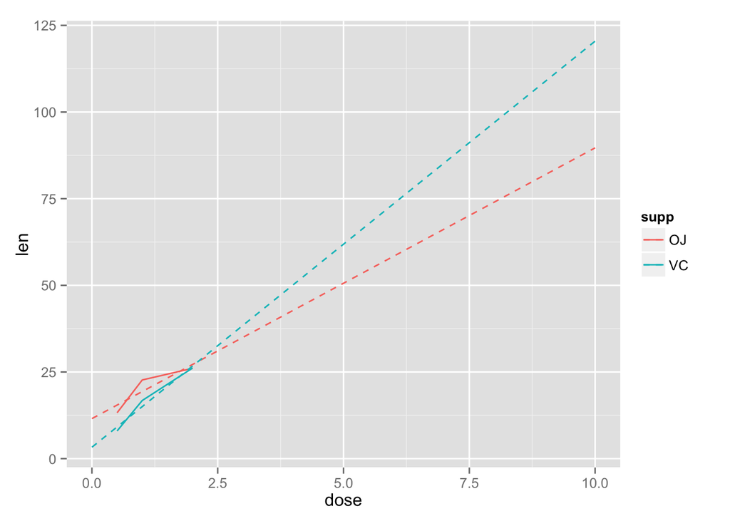

```r
(ggplot(ToothGrowth, aes(x = dose, y = len, color = supp))
  + geom_line(stat = "summary", fun.y = mean)
  + geom_line(data = d_pred, aes(y = predictions, color = supp), linetype = 2))
```

`The predictions are printed and plotted (dashed line) above.`

Now plot the residuals from the original model. How do they look? HINT: `?resid`

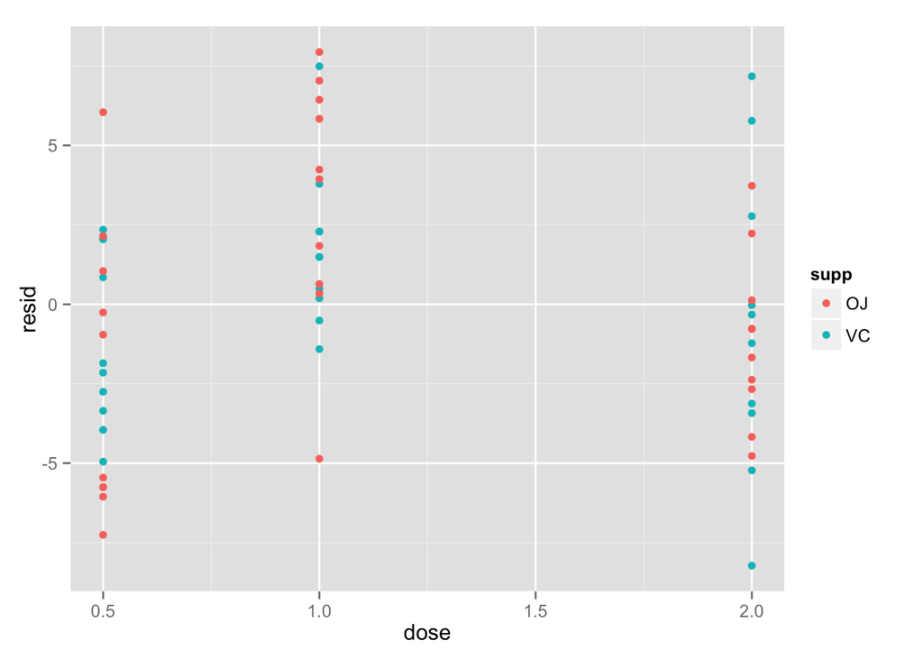

```r
ToothGrowth$resid <- mod_int$resid
ggplot(ToothGrowth, aes(x = dose, y = resid, color = supp)) + geom_point()
```

`` The residuals are not independent of dose, and this is especially true for the `OJ` group. This is because the model is not capturing the quadradic trend of dose that is especially prominent in the `OJ` group. ``

BONUS: test them for normality of distribution using a quantile-quantile plot.

HINT: `?qqplot` and `?qqnorm`

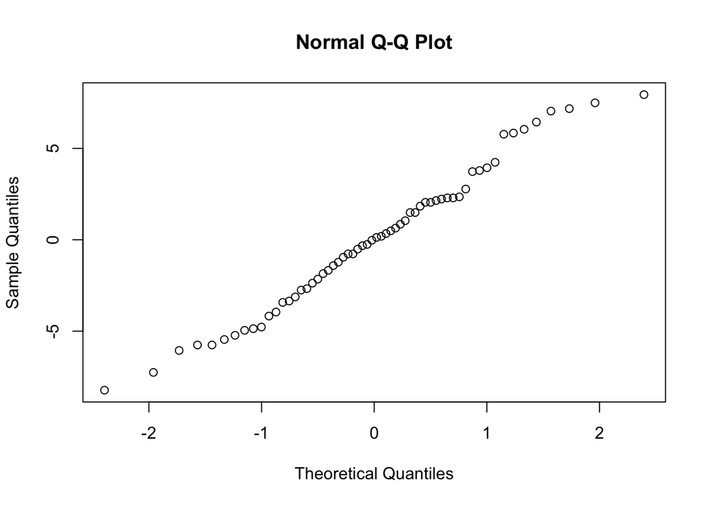

```r
qqnorm(ToothGrowth$resid)
```

`Looks fairly reasonable. A bit of a heavy right tail, likely due to our high residuals for the moderate level of dose.`

```r
rm(list = ls())
```

## 2B: Exploratory Linear Modeling

What the heck is going on? Load data from Frank, Vul, Saxe (2011, Infancy), a study in which we measured infants’ looking to hands in moving scenes. There were infants from 3 months all the way to about two years, and there were two movie conditions (`Faces_Medium`, in which kids played on a white background, and `Faces_Plus`, in which the backgrounds were more complex and the people in the videos were both kids and adults). Forgive our bad naming conventions.

Try to figure out what the most reasonable linear model of the data is.

```r
d <- read.csv("../data/FVS2011-hands.csv")
table(d$subid) # movie condition is within-subject
```

```
##
##   1   2   3   4   5   6   7   8   9  10  11  12  13  14  15  16  17  18
##   2   2   2   2   1   2   2   2   2   2   2   2   2   2   2   2   2   2
##  19  20  21  22  23  24  25  26  27  28  29  30  31  32  33  34  35  36
##   2   2   2   2   1   2   2   2   2   2   2   2   2   2   2   2   2   2
##  37  38  39  40  41  42  43  44  45  46  47  48  49  50  51  52  53  54
##   2   2   2   2   2   2   2   2   2   2   2   2   2   2   2   2   2   2
##  55  56  57  58  59  60  61  62  63  64  65  66  67  68  69  70  71  72
##   2   2   2   2   2   2   2   2   1   2   2   2   2   2   2   2   2   2
##  73  74  75  76  77  78  79  80  81  82  83  84  85  86  87  88  89  90
##   2   2   2   2   2   2   2   2   2   2   2   2   2   2   2   2   2   2
##  91  92  93  94  95  96  97  98  99 100 101 102 103 104 105 106 107 108
##   2   2   2   2   2   2   2   1   2   2   2   2   2   2   1   2   2   2
## 109 110 111 112 113 114 115 116 117 118 119
##   2   2   2   2   2   2   1   2   2   2   2
```

```
## stat_bin: binwidth defaulted to range/30. Use 'binwidth = x' to adjust this.
## stat_bin: binwidth defaulted to range/30. Use 'binwidth = x' to adjust this.
```

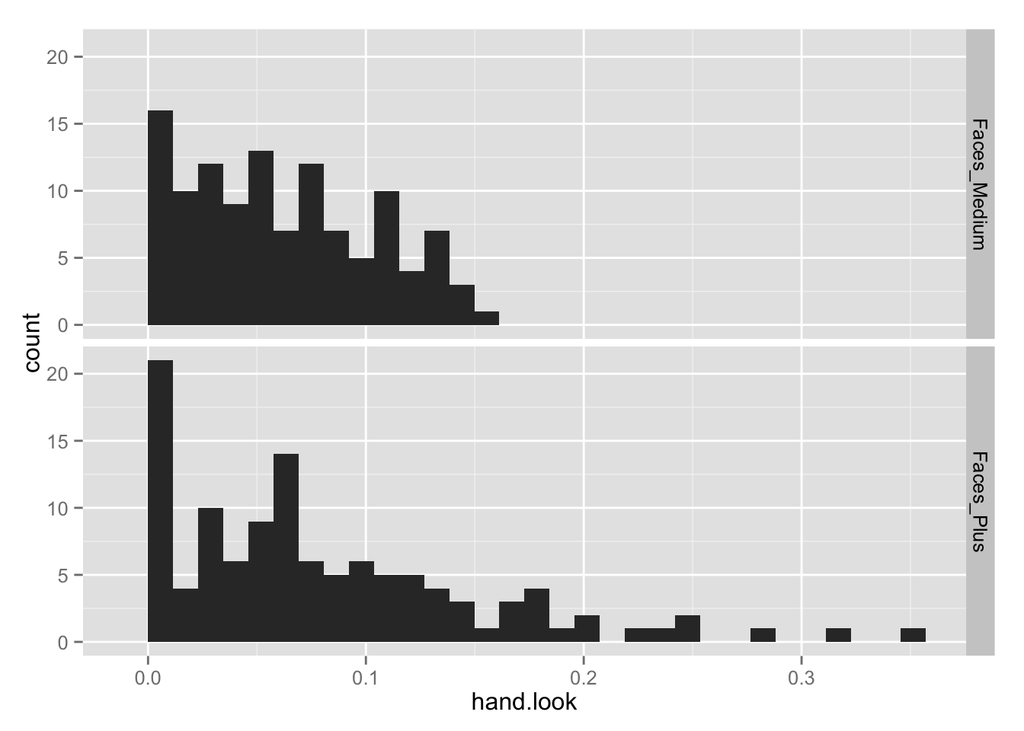

```r
# histogram
ggplot(d, aes(x = hand.look)) + geom_histogram() + facet_grid(condition ~ .)
```

```
## stat_bin: binwidth defaulted to range/30. Use 'binwidth = x' to adjust this.
```

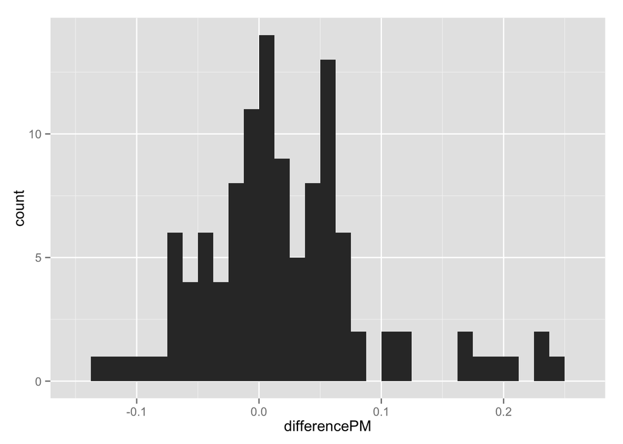

```r
# looks like a mixture of no looking + normal-ish for faces_plus, still skewed for faces_medium

# look at age (b/w ss factor)# older infants look longer, maybe an interaction with age

## now treat as a within-subjects design
d_diff <- spread(d, condition, hand.look) %>%
          mutate(differencePM = Faces_Plus - Faces_Medium)

# look at difference scores
ggplot(d_diff, aes(x = differencePM)) + geom_histogram()
```

```r
mean(d_diff$differencePM, na.rm = TRUE) #
```

```
## [1] 0.02095076
```

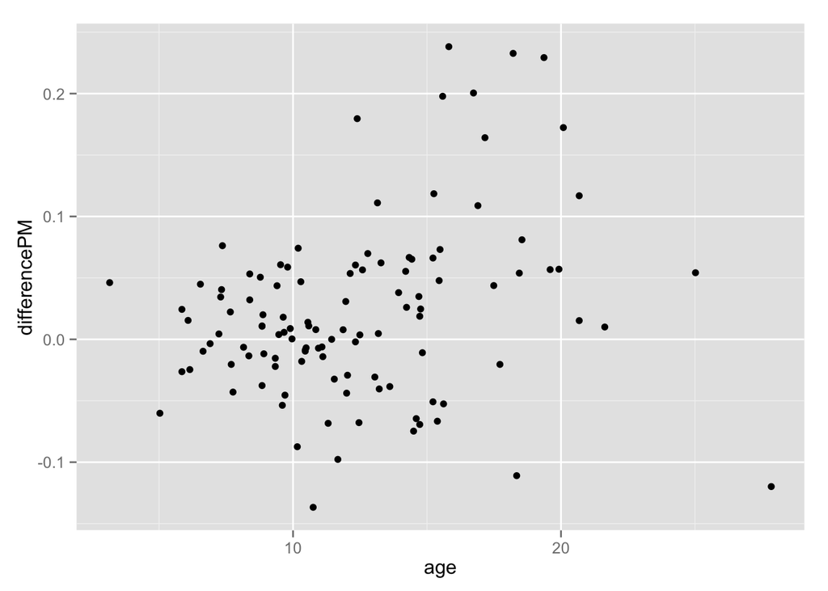

```r
# look at difference scores against age
ggplot(d_diff, aes(x = age, y = differencePM)) + geom_point()
```

```r
# the difference between conditions increases with age, more suppor age x condition interaction

# my model
mod <- lmer(hand.look ~ age * condition  + (1 | subid), data = d) # condition random effect unidentifiable (only 1 obs per ss)
summary(mod)
```

```
## Linear mixed model fit by REML ['lmerMod']
## Formula: hand.look ~ age * condition + (1 | subid)
##    Data: d
##
## REML criterion at convergence: -657.9
##
## Scaled residuals:
##     Min      1Q  Median      3Q     Max
## -3.2824 -0.6168 -0.0614  0.4640  3.9945
##
## Random effects:
##  Groups   Name        Variance  Std.Dev.
##  subid    (Intercept) 0.0005493 0.02344
##  Residual             0.0024313 0.04931
## Number of obs: 232, groups:  subid, 119
##
## Fixed effects:
##                          Estimate Std. Error t value
## (Intercept)              0.023014   0.015416   1.493
## age                      0.003059   0.001176   2.602
## conditionFaces_Plus     -0.028940   0.019649  -1.473
## age:conditionFaces_Plus  0.004000   0.001499   2.668
##
## Correlation of Fixed Effects:
##             (Intr) age    cndF_P
## age         -0.944
## cndtnFcs_Pl -0.646  0.611
## ag:cndtnF_P  0.610 -0.646 -0.944
```

Plot that model on the same plot as the data.

HINT: you can do this either using `predict` or (if you are feeling confident of your understanding of the models) using the built-in linear models in `ggplot`’s `geom_smooth`.

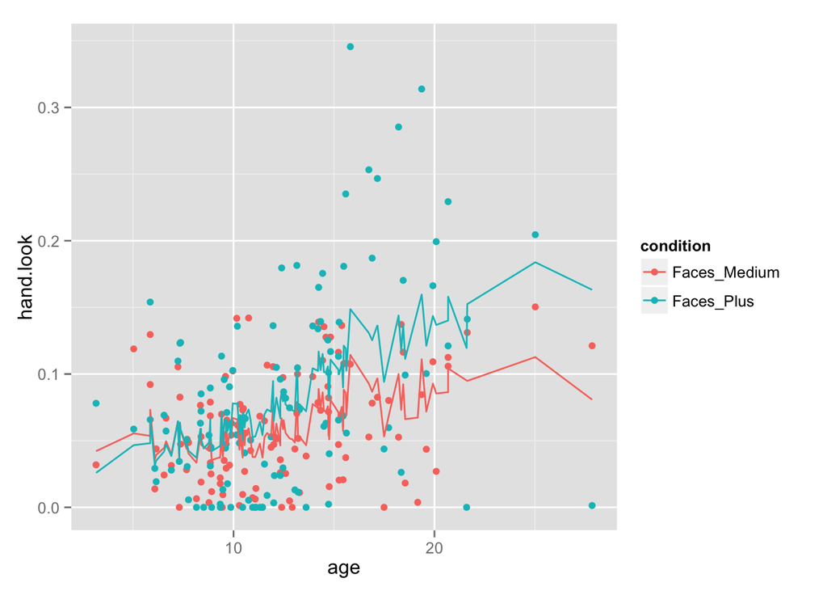

```r
d$fits <- predict(mod)
ggplot(d, aes(x = age, y = hand.look, color = condition)) + geom_point() + geom_path(aes(y = fits))
```

What do you conclude from this pattern of data?

# 3: Linear Mixed Effect Models

The goal here is to learn to use LMEMs using `lme4` and to compare them to standard by subject, by item LMs, as well as the standard (no repeated measures) fixed effects GLM.

The dataset here is from Stiller, Goodman, & Frank (2014), a paper on children’s pragmatic inferences. We saw the paradigm in the counterbalancing lecture: it’s three faces: a smiley, a smiley with glasses, and a smiley with a hat and glasses. When told “my friend has glasses” do kids pick the one with the glasses and no hat? `age.group` is the kids’ age group, `condition` is either “label,” described above, or “no label,” which was a control condition in which kids picked without hearing the term “glasses” at all.

```r
d <- read.csv("../data/scales.csv")
d$age.group <- factor(d$age.group)
```

Always begin with a histogram!

[output not shown]

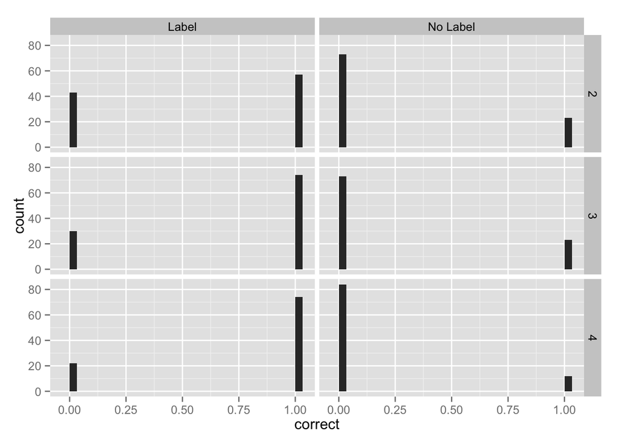

```r
ggplot(d, aes(x = correct)) + geom_histogram() + facet_grid(age.group ~ condition)
```

## Brief Confidence Interval Digression

Start out by setting up a function for a 95% CI using the normal approximation.

```r
ci95.norm <- function(x) {
  se <- sd(x) / sqrt(length(x))
  return(list(mean(x) - qnorm(.025) * se, mean(x) + qnorm(.025) * se))
}
```

But the number of participants in a group is likely to be < 30, so let’s also compute this with a t distribution.

```r
ci95.t <- function(x) {
  se <- sd(x) / sqrt(length(x))
  return(list(mean(x) + qt(.025, length(x) - 1) * se, mean(x) + qt(.975, length(x) - 1) * se))
}
```

On the other hand, maybe we should use bootstrap CIs because these are actually proportions, and the normal/t approximations don’t know that they are 0/1 bounded.

```r
library(boot)
library(bootstrap)
```

Take a look at `?boot` and `?bootci`. Note that the syntax for the `boot` library is terrible, so we’re going to use it to check some code that I use:

```r
theta <- function(x,xdata,na.rm=T) {mean(xdata[x],na.rm=na.rm)}
ci.low <- function(x,na.rm=T) {
  mean(x,na.rm=na.rm) -
    quantile(bootstrap(1:length(x),
                       10000,theta,x,na.rm=na.rm)$thetastar,.025,na.rm=na.rm)}
ci.high <- function(x,na.rm=T) {
  quantile(bootstrap(1:length(x),
                     10000,theta,x,na.rm=na.rm)$thetastar,.975,na.rm=na.rm) -
    mean(x,na.rm=na.rm)}
```

Now make 95% confidence intervals across participants using all the methods above:

- Normal
- t
- Bootstrap percentile using `boot.ci`
- Bootstrap percentile using my code

```r
print(ci95.norm(d$correct))
```

```
## [[1]]
## [1] 0.4875016
##
## [[2]]
## [1] 0.4070562
```

```r
print(ci95.t(d$correct))
```

```
## [[1]]
## [1] 0.4069731
##
## [[2]]
## [1] 0.4875847
```

```r
bootmean <- function(d, i) {mean(d[i])}
b <- boot(d$correct, statistic = bootmean, R = 10000)
print(boot.ci(b, type = 'basic'))
```

```
## BOOTSTRAP CONFIDENCE INTERVAL CALCULATIONS
## Based on 10000 bootstrap replicates
##
## CALL :
## boot.ci(boot.out = b, type = "basic")
##
## Intervals :
## Level      Basic
## 95%   ( 0.4065,  0.4864 )
## Calculations and Intervals on Original Scale
```

```r
print(list(mean(d$correct) - ci.low(d$correct), mean(d$correct) + ci.high(d$correct)))
```

```
## [[1]]
##      2.5%
## 0.4064626
##
## [[2]]
##     97.5%
## 0.4863946
```

Now plot the data by age and condition using `dplyr` and `ggplot2`. Plot some CIs on here - extra credit if you plot all of them and compare visually (you’ll need `position = position_dodge()` or some other way to offset them).

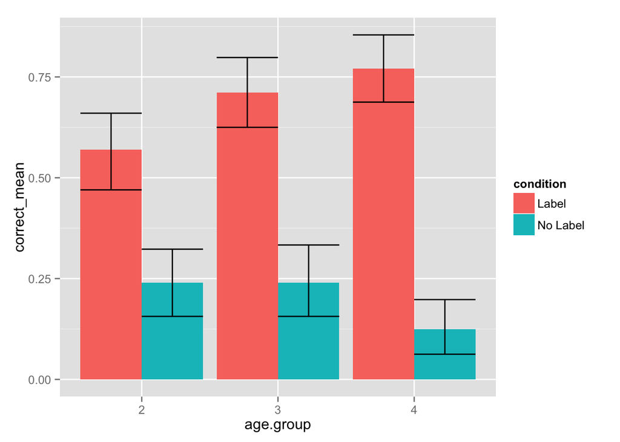

```r
ds <- group_by(d, age.group, condition) %>%
      summarise(correct_mean = mean(correct), correct_ci_low = ci.low(correct), correct_ci_high = ci.high(correct))
ggplot(ds, aes(x = age.group, y = correct_mean, fill = condition)) + geom_bar(stat='identity',position='dodge') + geom_errorbar(aes(ymin = correct_mean - correct_ci_low, ymax = correct_mean + correct_ci_high), position='dodge')
```

What do you conclude about confidence interval computation?

`One advantage of bootstrapped confidence intervals is that they can be asymmetric.`

## Back to LMEMs

```r
library(lme4)
```

OK, now do a basic GLM over the entire data frame, using `age.group`, `condition`, and their interaction to predict correctness. (If we were focusing on developmental issues, I would ask you to think about how to model age here, but let’s treat it as three discrete groups for now).

```r
d$age.group <- factor(d$age.group)
summary(glm(correct ~ age.group * condition, d, family = 'binomial'))
```

```
##
## Call:
## glm(formula = correct ~ age.group * condition, family = "binomial",
##     data = d)
##
## Deviance Residuals:
##     Min       1Q   Median       3Q      Max
## -1.7166  -0.7401  -0.5168   0.8250   2.0393
##
## Coefficients:
##                              Estimate Std. Error z value Pr(>|z|)
## (Intercept)                    0.2819     0.2020   1.395 0.162902
## age.group3                     0.6210     0.2961   2.098 0.035935 *
## age.group4                     0.9312     0.3159   2.948 0.003198 **
## conditionNo Label             -1.4368     0.3130  -4.590 4.43e-06 ***
## age.group3:conditionNo Label  -0.6210     0.4494  -1.382 0.167050
## age.group4:conditionNo Label  -1.7221     0.5022  -3.429 0.000605 ***
## ---
## Signif. codes:  0 '***' 0.001 '**' 0.01 '*' 0.05 '.' 0.1 ' ' 1
##
## (Dispersion parameter for binomial family taken to be 1)
##
##     Null deviance: 808.59  on 587  degrees of freedom
## Residual deviance: 648.74  on 582  degrees of freedom
## AIC: 660.74
##
## Number of Fisher Scoring iterations: 4
```

Let’s now use `dplyr` to get data frames for by-items (`msi`) and by-subjects (`mss`) analyses. `msi` should contain the mean ratings for every item and `mss` should contain the mean ratings for every subject.

```r
msi <- group_by(d, trial, age.group, condition) %>%
       summarise(correct = mean(correct))
mss <- group_by(d, subid, age.group, condition) %>%
       summarise(correct = mean(correct))
```

Now do standard linear models on each of these.

NOTE: These are not strictly correct either because of the normal approximation on percent correct (model doesn’t know it’s 0 - 1 bounded and could give you standard error that goes above 1). Again, useful to do and see what happens.

```r
mod.msi <- lm(correct ~ age.group * condition, msi)
mod.mss <- lm(correct ~ age.group * condition, mss)

summary(mod.msi)
```

```
##
## Call:
## lm(formula = correct ~ age.group * condition, data = msi)
##
## Residuals:
##      Min       1Q   Median       3Q      Max
## -0.21154 -0.07719  0.01042  0.07333  0.21154
##
## Coefficients:
##                              Estimate Std. Error t value Pr(>|t|)
## (Intercept)                   0.57000    0.05485  10.392 4.93e-09 ***
## age.group3                    0.14154    0.07757   1.825 0.084691 .
## age.group4                    0.20083    0.07757   2.589 0.018518 *
## conditionNo Label            -0.33042    0.07757  -4.260 0.000471 ***
## age.group3:conditionNo Label -0.14154    0.10970  -1.290 0.213292
## age.group4:conditionNo Label -0.31542    0.10970  -2.875 0.010068 *
## ---
## Signif. codes:  0 '***' 0.001 '**' 0.01 '*' 0.05 '.' 0.1 ' ' 1
##
## Residual standard error: 0.1097 on 18 degrees of freedom
## Multiple R-squared:  0.8752, Adjusted R-squared:  0.8405
## F-statistic: 25.24 on 5 and 18 DF,  p-value: 1.52e-07
```

```r
summary(mod.mss)
```

```
##
## Call:
## lm(formula = correct ~ age.group * condition, data = mss)
##
## Residuals:
##      Min       1Q   Median       3Q      Max
## -0.57000 -0.21154  0.01042  0.18000  0.51042
##
## Coefficients:
##                              Estimate Std. Error t value Pr(>|t|)
## (Intercept)                   0.57000    0.04420  12.897  < 2e-16 ***
## age.group3                    0.14154    0.06190   2.287 0.023714 *
## age.group4                    0.20083    0.06315   3.180 0.001810 **
## conditionNo Label            -0.33042    0.06315  -5.232 5.95e-07 ***
## age.group3:conditionNo Label -0.14154    0.08889  -1.592 0.113560
## age.group4:conditionNo Label -0.31542    0.08977  -3.514 0.000594 ***
## ---
## Signif. codes:  0 '***' 0.001 '**' 0.01 '*' 0.05 '.' 0.1 ' ' 1
##
## Residual standard error: 0.221 on 141 degrees of freedom
## Multiple R-squared:  0.5737, Adjusted R-squared:  0.5586
## F-statistic: 37.96 on 5 and 141 DF,  p-value: < 2.2e-16
```

Do ANOVA on these. Note that ANOVA doesn’t let you figure out what is going on with individual levels of age.

```r
anova(mod.msi)
```

```
## Analysis of Variance Table
##
## Response: correct
##                     Df  Sum Sq Mean Sq  F value    Pr(>F)
## age.group            2 0.02035 0.01018   0.8457   0.44564
## condition            1 1.39820 1.39820 116.1905 2.781e-09 ***
## age.group:condition  2 0.09984 0.04992   4.1482   0.03299 *
## Residuals           18 0.21661 0.01203
## ---
## Signif. codes:  0 '***' 0.001 '**' 0.01 '*' 0.05 '.' 0.1 ' ' 1
```

```r
anova(mod.mss)
```

```
## Analysis of Variance Table
##
## Response: correct
##                      Df Sum Sq Mean Sq  F value    Pr(>F)
## age.group             2 0.1461  0.0731   1.4962  0.227519
## condition             1 8.5172  8.5172 174.4023 < 2.2e-16 ***
## age.group:condition   2 0.6047  0.3024   6.1912  0.002647 **
## Residuals           141 6.8859  0.0488
## ---
## Signif. codes:  0 '***' 0.001 '**' 0.01 '*' 0.05 '.' 0.1 ' ' 1
```

On to linear mixed effect models. Create the maximal random effects model a la Barr et al. (2013). Does it converge? If not, what will you do to make it converge? (The internet can be your friend here).

HINT: try simplifying your model to a “semi-maximal” model. Bonus: try using a different fitting procedure on the maximal model.

HINT: make sure that you consider which random effects are appropriate. Consider which observations are within/between subjects. E.g. having a random coefficient for age by subject doesn’t make sense, because each subject has only one age.

```r
mod.lme.full <- glmer(correct ~ age.group * condition + (1 + condition | subid) + (1 + condition * age | trial), d, family = 'binomial')
mod.lme.semi <- glmer(correct ~ age.group * condition + (1 | subid) + (1 + age | trial), d, family = 'binomial')
summary(mod.lme.semi)
```

```
## Generalized linear mixed model fit by maximum likelihood (Laplace
##   Approximation) [glmerMod]
##  Family: binomial  ( logit )
## Formula: correct ~ age.group * condition + (1 | subid) + (1 + age | trial)
##    Data: d
##
##      AIC      BIC   logLik deviance df.resid
##    663.3    707.0   -321.6    643.3      578
##
## Scaled residuals:
##     Min      1Q  Median      3Q     Max
## -2.4804 -0.5800 -0.3113  0.6732  3.1049
##
## Random effects:
##  Groups Name        Variance Std.Dev. Corr
##  subid  (Intercept) 0.06360  0.2522
##  trial  (Intercept) 0.12541  0.3541
##         age         0.03569  0.1889   -1.00
## Number of obs: 588, groups:  subid, 147; trial, 4
##
## Fixed effects:
##                              Estimate Std. Error z value Pr(>|z|)
## (Intercept)                    0.2720     0.2241   1.213 0.224947
## age.group3                     0.6324     0.3190   1.982 0.047438 *
## age.group4                     0.9724     0.3751   2.593 0.009525 **
## conditionNo Label             -1.4617     0.3300  -4.430 9.43e-06 ***
## age.group3:conditionNo Label  -0.6666     0.4676  -1.426 0.153994
## age.group4:conditionNo Label  -1.8880     0.5368  -3.517 0.000437 ***
## ---
## Signif. codes:  0 '***' 0.001 '**' 0.01 '*' 0.05 '.' 0.1 ' ' 1
##
## Correlation of Fixed Effects:
##             (Intr) ag.gr3 ag.gr4 cndtNL a.3:NL
## age.group3  -0.535
## age.group4  -0.368  0.489
## conditnNLbl -0.621  0.393  0.318
## ag.grp3:cNL  0.425 -0.640 -0.256 -0.669
## ag.grp4:cNL  0.370 -0.260 -0.555 -0.575  0.436
```

`I tried removing random effects terms one at a time until the model converged. I would have preferred to keep in the random effect of condition for each subject but no model with that term would converge.`

How do these coefficients compare with the independent coefficients linear model? What do you conclude?

`The coefficients are similar. Presumably the error term should be what is changing the most.`

Which random effects make the most difference? Find out using `ranef`. Plot the random effects for subject and item.

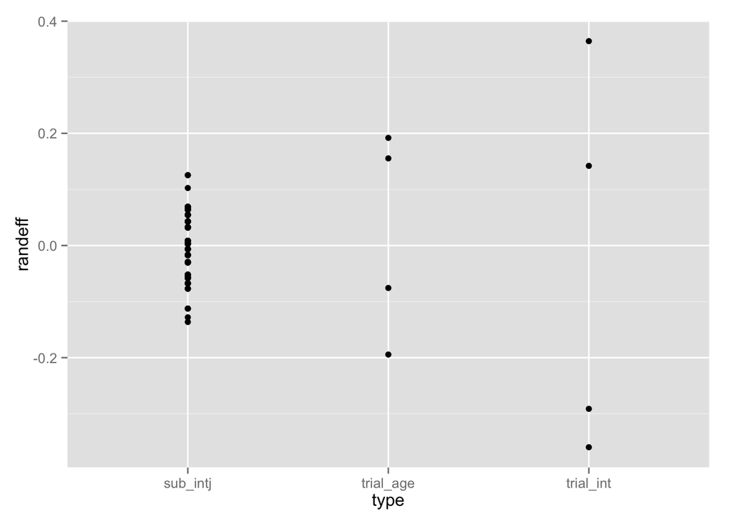

```r
dr <- data.frame(type = c(rep('sub_intj', nrow(ranef(mod.lme.semi)$subid)), rep('trial_int', 4), rep('trial_age', 4)), randeff = c(ranef(mod.lme.semi)$subid[,1], ranef(mod.lme.semi)$trial[,1], ranef(mod.lme.semi)$trial[,2]))
ggplot(dr, aes(x = type, y = randeff)) + geom_point()
```

`The trial random effects make the most difference, especially the intercept term for trial.`

Make the minimal random effects model with just a subject intecept. How does this compare?

```r
summary(glmer(correct ~ age.group * condition + (1 | subid), d, family = 'binomial'))
```

```
## Generalized linear mixed model fit by maximum likelihood (Laplace
##   Approximation) [glmerMod]
##  Family: binomial  ( logit )
## Formula: correct ~ age.group * condition + (1 | subid)
##    Data: d
##
##      AIC      BIC   logLik deviance df.resid
##    662.7    693.4   -324.4    648.7      581
##
## Scaled residuals:
##     Min      1Q  Median      3Q     Max
## -1.8385 -0.5597 -0.3737  0.6337  2.6414
##
## Random effects:
##  Groups Name        Variance Std.Dev.
##  subid  (Intercept) 0.02648  0.1627
## Number of obs: 588, groups:  subid, 147
##
## Fixed effects:
##                              Estimate Std. Error z value Pr(>|z|)
## (Intercept)                    0.2837     0.2056   1.380 0.167600
## age.group3                     0.6248     0.3014   2.073 0.038189 *
## age.group4                     0.9365     0.3220   2.908 0.003633 **
## conditionNo Label             -1.4456     0.3223  -4.485  7.3e-06 ***
## age.group3:conditionNo Label  -0.6249     0.4561  -1.370 0.170660
## age.group4:conditionNo Label  -1.7305     0.5104  -3.390 0.000699 ***
## ---
## Signif. codes:  0 '***' 0.001 '**' 0.01 '*' 0.05 '.' 0.1 ' ' 1
##
## Correlation of Fixed Effects:
##             (Intr) ag.gr3 ag.gr4 cndtNL a.3:NL
## age.group3  -0.675
## age.group4  -0.630  0.443
## conditnNLbl -0.646  0.419  0.387
## ag.grp3:cNL  0.446 -0.661 -0.293 -0.675
## ag.grp4:cNL  0.395 -0.282 -0.635 -0.593  0.438
```

`It is similar but the coefficients are a little different and the p-values are a little lower.`

Get an estimate of the significance value for the coefficient on the `age*condition` interaction by using anova to compare between your semi-maximal model and the model without an intercept.

```r
mod.lme.semi.red <- glmer(correct ~ age.group + condition + (1 | subid) + (1 + age | trial), d, family = 'binomial')
summary(mod.lme.semi)
```

```
## Generalized linear mixed model fit by maximum likelihood (Laplace
##   Approximation) [glmerMod]
##  Family: binomial  ( logit )
## Formula: correct ~ age.group * condition + (1 | subid) + (1 + age | trial)
##    Data: d
##
##      AIC      BIC   logLik deviance df.resid
##    663.3    707.0   -321.6    643.3      578
##
## Scaled residuals:
##     Min      1Q  Median      3Q     Max
## -2.4804 -0.5800 -0.3113  0.6732  3.1049
##
## Random effects:
##  Groups Name        Variance Std.Dev. Corr
##  subid  (Intercept) 0.06360  0.2522
##  trial  (Intercept) 0.12541  0.3541
##         age         0.03569  0.1889   -1.00
## Number of obs: 588, groups:  subid, 147; trial, 4
##
## Fixed effects:
##                              Estimate Std. Error z value Pr(>|z|)
## (Intercept)                    0.2720     0.2241   1.213 0.224947
## age.group3                     0.6324     0.3190   1.982 0.047438 *
## age.group4                     0.9724     0.3751   2.593 0.009525 **
## conditionNo Label             -1.4617     0.3300  -4.430 9.43e-06 ***
## age.group3:conditionNo Label  -0.6666     0.4676  -1.426 0.153994
## age.group4:conditionNo Label  -1.8880     0.5368  -3.517 0.000437 ***
## ---
## Signif. codes:  0 '***' 0.001 '**' 0.01 '*' 0.05 '.' 0.1 ' ' 1
##
## Correlation of Fixed Effects:
##             (Intr) ag.gr3 ag.gr4 cndtNL a.3:NL
## age.group3  -0.535
## age.group4  -0.368  0.489
## conditnNLbl -0.621  0.393  0.318
## ag.grp3:cNL  0.425 -0.640 -0.256 -0.669
## ag.grp4:cNL  0.370 -0.260 -0.555 -0.575  0.436
```

```r
anova(mod.lme.semi.red, mod.lme.semi)
```

```
## Data: d
## Models:
## mod.lme.semi.red: correct ~ age.group + condition + (1 | subid) + (1 + age | trial)
## mod.lme.semi: correct ~ age.group * condition + (1 | subid) + (1 + age | trial)
##                  Df    AIC    BIC  logLik deviance Chisq Chi Df Pr(>Chisq)
## mod.lme.semi.red  8 672.38 707.39 -328.19   656.38
## mod.lme.semi     10 663.26 707.03 -321.63   643.26 13.12      2   0.001416
##
## mod.lme.semi.red
## mod.lme.semi     **
## ---
## Signif. codes:  0 '***' 0.001 '**' 0.01 '*' 0.05 '.' 0.1 ' ' 1
```

`I'm not quite sure what this question is asking (why we would remove the intercept to test the age*condition interaction). I removed the interaction term and ompared the models, yielding p = .001416`